# Background

Business communities in the United States are facing high demand for human resources, but one of the constant challenges is identifying and attracting the right talent, which is perhaps the most important element in remaining competitive. Companies in the United States look for hard-working, talented, and qualified individuals both locally as well as abroad.

The Immigration and Nationality Act (INA) of the US permits foreign workers to come to the United States to work on either a temporary or permanent basis. The act also protects US workers against adverse impacts on their wages or working conditions by ensuring US employers' compliance with statutory requirements when they hire foreign workers to fill workforce shortages. The immigration programs are administered by the Office of Foreign Labor Certification (OFLC).

OFLC processes job certification applications for employers seeking to bring foreign workers into the United States and grants certifications in those cases where employers can demonstrate that there are not sufficient US workers available to perform the work at wages that meet or exceed the wage paid for the occupation in the area of intended employment.

# Objective

In FY 2016, the OFLC processed 775,979 employer applications for 1,699,957 positions for temporary and permanent labor certifications. This was a nine percent increase in the overall number of processed applications from the previous year. The process of reviewing every case is becoming a tedious task as the number of applicants is increasing every year.

The increasing number of applicants every year calls for a Machine Learning based solution that can help in shortlisting the candidates having higher chances of VISA approval. OFLC has hired the firm EasyVisa for data-driven solutions. You as a data scientist at EasyVisa have to analyze the data provided and, with the help of a classification model:

Facilitate the process of visa approvals. Recommend a suitable profile for the applicants for whom the visa should be certified or denied based on the drivers that significantly influence the case status.

# Key Questions

1. Those with higher education may want to travel abroad for a well-paid job. Does education play a role in Visa certification?
2. How does the visa status vary across different continents?
3. Experienced professionals might look abroad for opportunities to improve their lifestyles and career development. Does work experience influence visa status?
4. In the United States, employees are paid at different intervals. Which pay unit is most likely to be certified for a visa?
5. The US government has established a prevailing wage to protect local talent and foreign workers. How does the visa status change with the prevailing wage?

# Data Description

1. case_id: ID of each visa application
2. continent: Information of continent the employee
3. education_of_employee: Information of education of the employee
4. has_job_experience: Does the employee has any job experience? Y= Yes; N = No
5. requires_job_training: Does the employee require any job training? Y = Yes; N = No
6. no_of_employees: Number of employees in the employer's company
7. yr_of_estab: Year in which the employer's company was established
8. region_of_employment: Information of foreign worker's intended region of employment in the US.
9. prevailing_wage: Average wage paid to similarly employed workers in a specific occupation in the area of intended employment. The purpose of the prevailing wage is to ensure that the foreign worker is not underpaid compared to other workers offering the same or similar service in the same area of employment.
10. unit_of_wage: Unit of prevailing wage. Values include Hourly, Weekly, Monthly, and Yearly.
11. full_time_position: Is the position of work full-time? Y = Full-Time Position; N = Part-Time Position
12. case_status: Flag indicating if the Visa was certified or denied

```python
# import the important packages
import pandas as pd
# library used for data manipulation and analysis

import numpy as np  # library used for working with arrays

import matplotlib.pyplot as plt  # library for visualization

import seaborn as sns  # library for visualization

%matplotlib inline

import scipy.stats as stats  # this library contains a large number of probability distributions as well as a growing library of statistical functions
from scipy.stats import uniform
from scipy.stats import norm
from scipy.stats import expon
from scipy.stats import binom
from scipy.stats import ttest_1samp
from scipy.stats import ttest_ind
from scipy.stats import ttest_rel
from statsmodels.stats.proportion import proportions_ztest
from scipy.stats import chi2
from scipy.stats import f
from scipy.stats import chi2_contingency
from scipy.stats import levene
from scipy.stats import f_oneway
from statsmodels.stats.multicomp import pairwise_tukeyhsd
import pylab
import scipy.stats as stats
import statsmodels.stats.api as sms
from statsmodels.compat import lzip


from sklearn.linear_model import LinearRegression
from sklearn.model_selection import train_test_split #sklearn package's randomized data splitting function
from sklearn.preprocessing import PolynomialFeatures
from sklearn import linear_model
from sklearn.metrics import mean_squared_error
import statsmodels.api as sm
from sklearn.metrics import mean_absolute_error, mean_squared_error, r2_score
from sklearn.tree import DecisionTreeClassifier
from sklearn import tree
from sklearn.linear_model import LogisticRegression
from sklearn import metrics
from sklearn.tree import DecisionTreeClassifier
from sklearn import tree
from sklearn.model_selection import GridSearchCV
from sklearn.ensemble import BaggingClassifier
from sklearn.ensemble import RandomForestClassifier
from sklearn.metrics import roc_auc_score
from sklearn.metrics import confusion_matrix, classification_report
from sklearn.metrics import accuracy_score,precision_score,recall_score,f1_score
from sklearn.ensemble import AdaBoostClassifier, GradientBoostingClassifier
!pip install xgboost
from xgboost import XGBClassifier

pd.set_option('display.max_columns',None)
pd.set_option('display.max_rows',200)
```

```python
book = pd.read_csv('EasyVisa.csv')
book.head(10)
```

|  | case_id | continent | education_of_employee | has_job_experience | requires_job_training | no_of_employees | yr_of_estab | region_of_employment | prevailing_wage | unit_of_wage | full_time_position | case_status |
| --- | --- | --- | --- | --- | --- | --- | --- | --- | --- | --- | --- | --- |
| 0 | EZYV01 | Asia | High School | N | N | 14513 | 2007 | West | 592.2029 | Hour | Y | Denied |
| 1 | EZYV02 | Asia | Master's | Y | N | 2412 | 2002 | Northeast | 83425.6500 | Year | Y | Certified |
| 2 | EZYV03 | Asia | Bachelor's | N | Y | 44444 | 2008 | West | 122996.8600 | Year | Y | Denied |
| 3 | EZYV04 | Asia | Bachelor's | N | N | 98 | 1897 | West | 83434.0300 | Year | Y | Denied |
| 4 | EZYV05 | Africa | Master's | Y | N | 1082 | 2005 | South | 149907.3900 | Year | Y | Certified |
| 5 | EZYV06 | Asia | Master's | Y | N | 2339 | 2012 | South | 78252.1400 | Year | Y | Certified |
| 6 | EZYV07 | Asia | Bachelor's | N | N | 4985 | 1994 | South | 53635.3900 | Year | Y | Certified |
| 7 | EZYV08 | North America | Bachelor's | Y | N | 3035 | 1924 | West | 418.2298 | Hour | Y | Denied |
| 8 | EZYV09 | Asia | Bachelor's | N | N | 4810 | 2012 | Midwest | 74362.1900 | Year | Y | Certified |
| 9 | EZYV10 | Europe | Doctorate | Y | N | 2251 | 1995 | South | 67514.7600 | Year | Y | Certified |

```python
book.shape
```

```
(25480, 12)
```

```python
book.info()
```

```
<class 'pandas.core.frame.DataFrame'>
RangeIndex: 25480 entries, 0 to 25479
Data columns (total 12 columns):
 #   Column                 Non-Null Count  Dtype
---  ------                 --------------  -----
 0   case_id                25480 non-null  object
 1   continent              25480 non-null  object
 2   education_of_employee  25480 non-null  object
 3   has_job_experience     25480 non-null  object
 4   requires_job_training  25480 non-null  object
 5   no_of_employees        25480 non-null  int64
 6   yr_of_estab            25480 non-null  int64
 7   region_of_employment   25480 non-null  object
 8   prevailing_wage        25480 non-null  float64
 9   unit_of_wage           25480 non-null  object
 10  full_time_position     25480 non-null  object
 11  case_status            25480 non-null  object
dtypes: float64(1), int64(2), object(9)
memory usage: 2.3+ MB
```

**Observations**

- There are 25,480 rows and 12 columns.
- Column names are all written properly and can be used easily.
- Some variables will have to be converted.
- Dependent variable is *case_status*.

```python
# let's create a copy of the data to avoid any changes to original data
bc = book.copy()
```

## Data Prprocessing

### Missing Value Treatment

```python
# checking for missing values
bc.isnull().sum()
```

```
case_id                  0
continent                0
education_of_employee    0
has_job_experience       0
requires_job_training    0
no_of_employees          0
yr_of_estab              0
region_of_employment     0
prevailing_wage          0
unit_of_wage             0
full_time_position       0
case_status              0
dtype: int64
```

There are no missing values

```python
bc.describe(include='all').T
```

|  | count | unique | top | freq | mean | std | min | 25% | 50% | 75% | max |
| --- | --- | --- | --- | --- | --- | --- | --- | --- | --- | --- | --- |
| case_id | 25480 | 25480 | EZYV14718 | 1 | NaN | NaN | NaN | NaN | NaN | NaN | NaN |
| continent | 25480 | 6 | Asia | 16861 | NaN | NaN | NaN | NaN | NaN | NaN | NaN |
| education_of_employee | 25480 | 4 | Bachelor's | 10234 | NaN | NaN | NaN | NaN | NaN | NaN | NaN |
| has_job_experience | 25480 | 2 | Y | 14802 | NaN | NaN | NaN | NaN | NaN | NaN | NaN |
| requires_job_training | 25480 | 2 | N | 22525 | NaN | NaN | NaN | NaN | NaN | NaN | NaN |
| no_of_employees | 25480.0 | NaN | NaN | NaN | 5667.04321 | 22877.928848 | -26.0 | 1022.0 | 2109.0 | 3504.0 | 602069.0 |
| yr_of_estab | 25480.0 | NaN | NaN | NaN | 1979.409929 | 42.366929 | 1800.0 | 1976.0 | 1997.0 | 2005.0 | 2016.0 |
| region_of_employment | 25480 | 5 | Northeast | 7195 | NaN | NaN | NaN | NaN | NaN | NaN | NaN |
| prevailing_wage | 25480.0 | NaN | NaN | NaN | 74455.814592 | 52815.942327 | 2.1367 | 34015.48 | 70308.21 | 107735.5125 | 319210.27 |
| unit_of_wage | 25480 | 4 | Year | 22962 | NaN | NaN | NaN | NaN | NaN | NaN | NaN |
| full_time_position | 25480 | 2 | Y | 22773 | NaN | NaN | NaN | NaN | NaN | NaN | NaN |
| case_status | 25480 | 2 | Certified | 17018 | NaN | NaN | NaN | NaN | NaN | NaN | NaN |

### Conversion to Categorical Variables

```python
for feature in bc.columns: # Loop through all columns in the dataframe
    if bc[feature].dtype == 'object': # Only apply for columns with categorical strings
        bc[feature] = pd.Categorical(bc[feature])# Replace strings with an integer
bc.head(10)
```

|  | case_id | continent | education_of_employee | has_job_experience | requires_job_training | no_of_employees | yr_of_estab | region_of_employment | prevailing_wage | unit_of_wage | full_time_position | case_status |
| --- | --- | --- | --- | --- | --- | --- | --- | --- | --- | --- | --- | --- |
| 0 | EZYV01 | Asia | High School | N | N | 14513 | 2007 | West | 592.2029 | Hour | Y | Denied |
| 1 | EZYV02 | Asia | Master's | Y | N | 2412 | 2002 | Northeast | 83425.6500 | Year | Y | Certified |
| 2 | EZYV03 | Asia | Bachelor's | N | Y | 44444 | 2008 | West | 122996.8600 | Year | Y | Denied |
| 3 | EZYV04 | Asia | Bachelor's | N | N | 98 | 1897 | West | 83434.0300 | Year | Y | Denied |
| 4 | EZYV05 | Africa | Master's | Y | N | 1082 | 2005 | South | 149907.3900 | Year | Y | Certified |
| 5 | EZYV06 | Asia | Master's | Y | N | 2339 | 2012 | South | 78252.1400 | Year | Y | Certified |
| 6 | EZYV07 | Asia | Bachelor's | N | N | 4985 | 1994 | South | 53635.3900 | Year | Y | Certified |
| 7 | EZYV08 | North America | Bachelor's | Y | N | 3035 | 1924 | West | 418.2298 | Hour | Y | Denied |
| 8 | EZYV09 | Asia | Bachelor's | N | N | 4810 | 2012 | Midwest | 74362.1900 | Year | Y | Certified |
| 9 | EZYV10 | Europe | Doctorate | Y | N | 2251 | 1995 | South | 67514.7600 | Year | Y | Certified |

```python
bc.info()
```

```
<class 'pandas.core.frame.DataFrame'>
RangeIndex: 25480 entries, 0 to 25479
Data columns (total 12 columns):
 #   Column                 Non-Null Count  Dtype
---  ------                 --------------  -----
 0   case_id                25480 non-null  category
 1   continent              25480 non-null  category
 2   education_of_employee  25480 non-null  category
 3   has_job_experience     25480 non-null  category
 4   requires_job_training  25480 non-null  category
 5   no_of_employees        25480 non-null  int64
 6   yr_of_estab            25480 non-null  int64
 7   region_of_employment   25480 non-null  category
 8   prevailing_wage        25480 non-null  float64
 9   unit_of_wage           25480 non-null  category
 10  full_time_position     25480 non-null  category
 11  case_status            25480 non-null  category
dtypes: category(9), float64(1), int64(2)
memory usage: 2.0 MB
```

## EDA

### Numerical Variables

```python
# function to plot a boxplot and a histogram along the same scale.

def histogram_boxplot(data, feature, figsize=(12, 7), kde=False, bins=None):
    f2, (ax_box2, ax_hist2) = plt.subplots(
        nrows=2,  # Number of rows of the subplot grid= 2
        sharex=True,  # x-axis will be shared among all subplots
        gridspec_kw={"height_ratios": (0.25, 0.75)},
        figsize=figsize,
    )  # creating the 2 subplots
    sns.boxplot(
        data=data, x=feature, ax=ax_box2, showmeans=True, color="violet"
    )  # boxplot will be created and a star will indicate the mean value of the column
    sns.histplot(
        data=data, x=feature, kde=kde, ax=ax_hist2, bins=bins, palette="winter"
    ) if bins else sns.histplot(
        data=data, x=feature, kde=kde, ax=ax_hist2
    )  # For histogram
    ax_hist2.axvline(
        data[feature].mean(), color="green", linestyle="--"
    )  # Add mean to the histogram
    ax_hist2.axvline(
        data[feature].median(), color="black", linestyle="-"
    )  # Add median to the histogram
```

#### Observations on Prevailing Wage

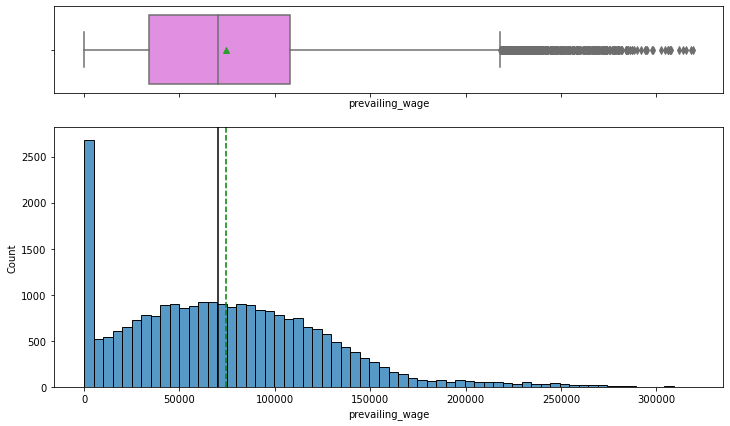

```python
histogram_boxplot(bc, 'prevailing_wage')
```

#### Observations on Year of Establishment

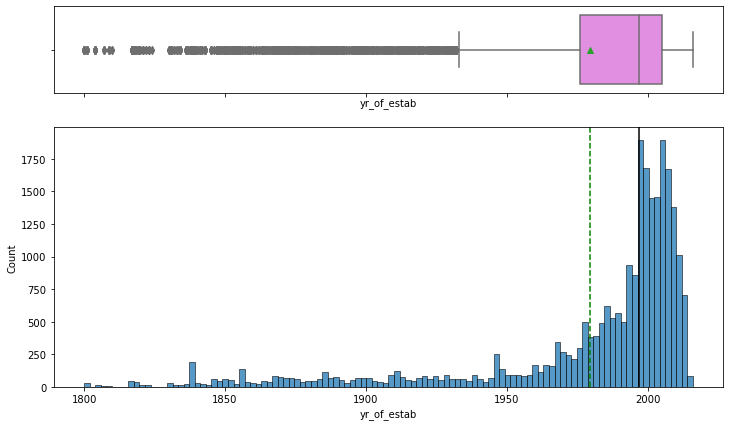

```python
histogram_boxplot(bc, 'yr_of_estab')
```

#### Observations

```python
# function to create labeled barplots


def labeled_barplot(data, feature, perc=False, n=None):
    """
    Barplot with percentage at the top

    data: dataframe
    feature: dataframe column
    perc: whether to display percentages instead of count (default is False)
    n: displays the top n category levels (default is None, i.e., display all levels)
    """

    total = len(data[feature])  # length of the column
    count = data[feature].nunique()
    if n is None:
        plt.figure(figsize=(count + 1, 5))
    else:
        plt.figure(figsize=(n + 1, 5))

    plt.xticks(rotation=90, fontsize=15)
    ax = sns.countplot(
        data=data,
        x=feature,
        palette="Paired",
        order=data[feature].value_counts().index[:n].sort_values(),
    )

    for p in ax.patches:
        if perc == True:
            label = "{:.1f}%".format(
                100 * p.get_height() / total
            )  # percentage of each class of the category
        else:
            label = p.get_height()  # count of each level of the category

        x = p.get_x() + p.get_width() / 2  # width of the plot
        y = p.get_height()  # height of the plot

        ax.annotate(
            label,
            (x, y),
            ha="center",
            va="center",
            size=12,
            xytext=(0, 5),
            textcoords="offset points",
        )  # annotate the percentage

    plt.show()  # show the plot
```

```python
# function to plot stacked bar chart


def stacked_barplot(data, predictor, target):
    """
    Print the category counts and plot a stacked bar chart

    data: dataframe
    predictor: independent variable
    target: target variable
    """
    count = data[predictor].nunique()
    sorter = data[target].value_counts().index[-1]
    tab1 = pd.crosstab(data[predictor], data[target], margins=True).sort_values(
        by=sorter, ascending=False
    )
    print(tab1)
    print("-" * 120)
    tab = pd.crosstab(data[predictor], data[target], normalize="index").sort_values(
        by=sorter, ascending=False
    )
    tab.plot(kind="bar", stacked=True, figsize=(count + 1, 5))
    plt.legend(
        loc="lower left",
        frameon=False,
    )
    plt.legend(loc="upper left", bbox_to_anchor=(1, 1))
    plt.show()
```

#### Observations on Visa Status

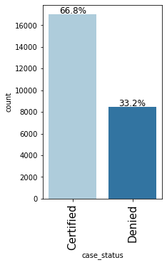

```python
labeled_barplot(bc, "case_status", perc=True)
```

#### Observations

1. The number of certified applicants is 66.8% indicating that most of the applicants get their visa certified

#### Observations on Continent

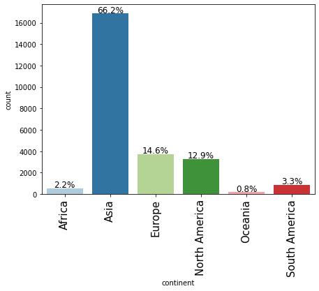

```python
labeled_barplot(bc, "continent", perc=True)
```

#### Observations

1. Asia has the highest number (~16,900) of visa applicants by a very large margin
2. Europe and North America combined have approximately 7,000 applicants, which is slightly more than a quarter
3. The other 3 continents contribute very little

#### Observations on Employment Region

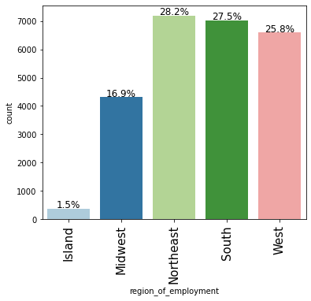

```python
labeled_barplot(bc, "region_of_employment", perc=True)
```

#### Observations

1. The Northeast has the highest number of applicants, with the South and West coming a close second and third respectively. Together they make up over 80% of applications

#### Observations on Region of Employment wrt Prevailing Wage

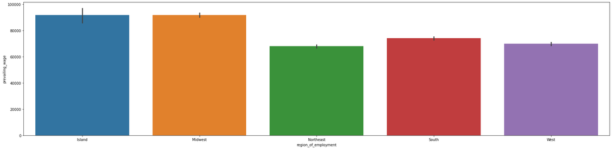

```python
plt.figure(figsize=(30, 7))
sns.barplot(y="prevailing_wage", x="region_of_employment", data=bc)
plt.show()
```

#### Observations

1. The highest prevailing wages come from the Island and Midwest regions. However, as shown in the previous observation, they have the lowest number of applicants indicating that they are probably known for not taking in as many applicants as the other regions

#### Observations on Region of Employment wrt Number of Employees

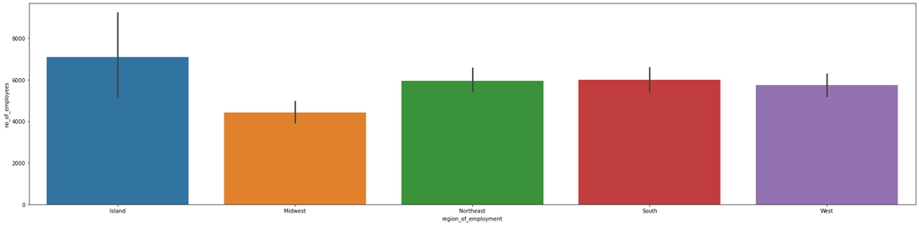

```python
plt.figure(figsize=(30, 7))
sns.barplot(y="no_of_employees", x="region_of_employment", data=bc)
plt.show()
```

#### Observations on Continent wrt Job Experience

```
has_job_experience      N      Y    All
continent
All                 10678  14802  25480
Asia                 7071   9790  16861
Europe               1576   2156   3732
North America        1348   1944   3292
South America         377    475    852
Africa                217    334    551
Oceania                89    103    192
------------------------------------------------------------------------------------------------------------------------
```

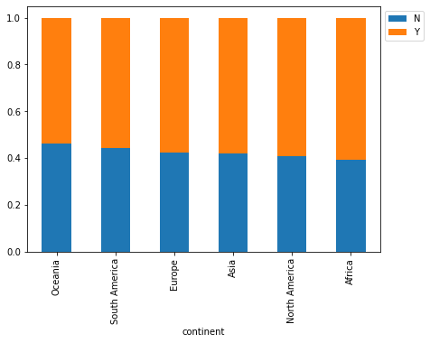

```python
stacked_barplot(bc, "continent", "has_job_experience")
```

#### Observations on Continent wrt Education Status

```
education_of_employee  Bachelor's  Doctorate  High School  Master's    All
continent
All                         10234       2192         3420      9634  25480
Asia                         7168        923         2290      6480  16861
Europe                       1299        846          490      1097   3732
North America                1225        258          401      1408   3292
South America                 333         89          137       293    852
Africa                        143         54           66       288    551
Oceania                        66         22           36        68    192
------------------------------------------------------------------------------------------------------------------------
```

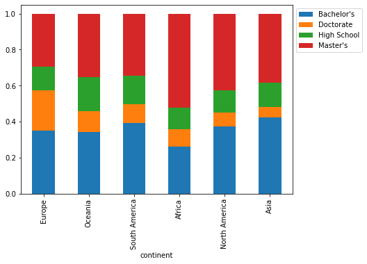

```python
stacked_barplot(bc, "continent", "education_of_employee")
```

#### Observations

1. Europe has the highest percentage of Doctorates while Asia has the highest percentage of Bachelor degrees.
2. Africa has the highest percentage of Masters
3. The degree split is very varied amongst the various continents

### Bivarate Analysis

```
case_status           Certified  Denied    All
region_of_employment
All                       17018    8462  25480
Northeast                  4526    2669   7195
West                       4100    2486   6586
South                      4913    2104   7017
Midwest                    3253    1054   4307
Island                      226     149    375
------------------------------------------------------------------------------------------------------------------------
```

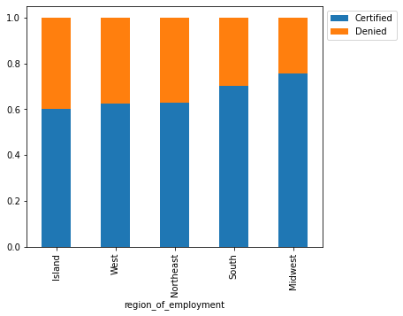

```python
stacked_barplot(bc, "region_of_employment", "case_status")
```

#### Observations

1. Midwest gives the highest number of certified applicants while Island has the lowest number.
2. However, the disparity is not too large with none of the regions reach 80%

#### Visa Status wrt Education Status

```
case_status            Certified  Denied    All
education_of_employee
All                        17018    8462  25480
Bachelor's                  6367    3867  10234
High School                 1164    2256   3420
Master's                    7575    2059   9634
Doctorate                   1912     280   2192
------------------------------------------------------------------------------------------------------------------------
```

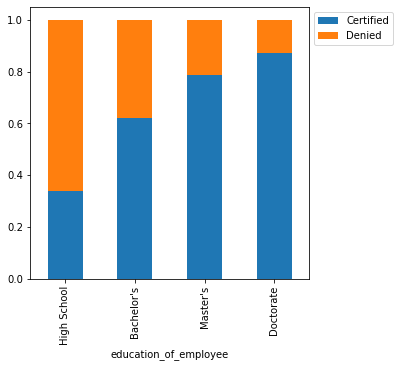

```python
stacked_barplot(bc, "education_of_employee", "case_status")
```

#### Observations

1. Candidates with a doctorate seem to have a much higher rate of being certified with about 90% of them being certified.
2. Candidates with only a High School Diploma do not get certified with only about 30% getting certified

#### Visa Status wrt Continent

```
case_status    Certified  Denied    All
continent
All                17018    8462  25480
Asia               11012    5849  16861
North America       2037    1255   3292
Europe              2957     775   3732
South America        493     359    852
Africa               397     154    551
Oceania              122      70    192
------------------------------------------------------------------------------------------------------------------------
```

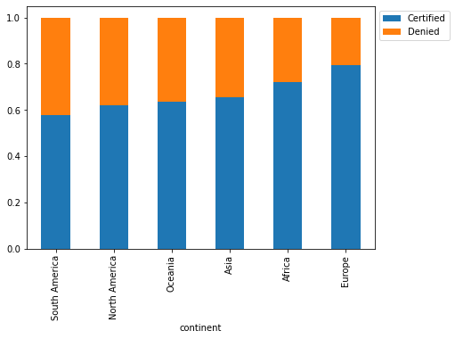

```python
stacked_barplot(bc, "continent", "case_status")
```

#### Observations

1. South America has the lowest rate of visa certification while Europe has the highest.
2. Europe is well above the average indicating that more European workers get their visa certified

#### Visa Status wrt Work Experience

```
case_status         Certified  Denied    All
has_job_experience
All                     17018    8462  25480
N                        5994    4684  10678
Y                       11024    3778  14802
------------------------------------------------------------------------------------------------------------------------
```

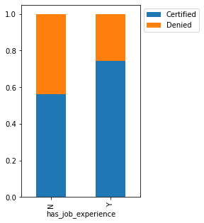

```python
stacked_barplot(bc, "has_job_experience", "case_status")
```

#### Visa Status wrt Payment Schedule

```
case_status   Certified  Denied    All
unit_of_wage
All               17018    8462  25480
Year              16047    6915  22962
Hour                747    1410   2157
Week                169     103    272
Month                55      34     89
------------------------------------------------------------------------------------------------------------------------
```

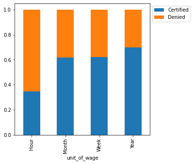

```python
stacked_barplot(bc, "unit_of_wage", "case_status")
```

#### Observations

1. Applicants that get yearly wages have a higher chance of getting their visas certified while those that work for hourly wages have the lowest chances

#### Visa Status wrt Prevailing Wage

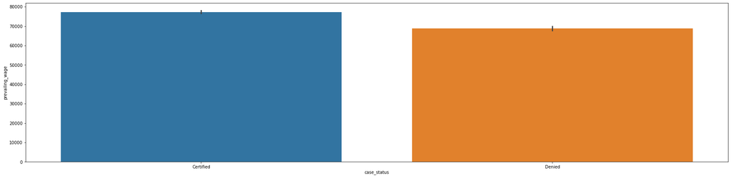

```python
plt.figure(figsize=(30,7))
sns.barplot(x='case_status',y='prevailing_wage',data=bc)
plt.show()
```

#### Observations

1. The higher wages seem to have more visas certified than those with lower prevailing wages

### Data Correlation

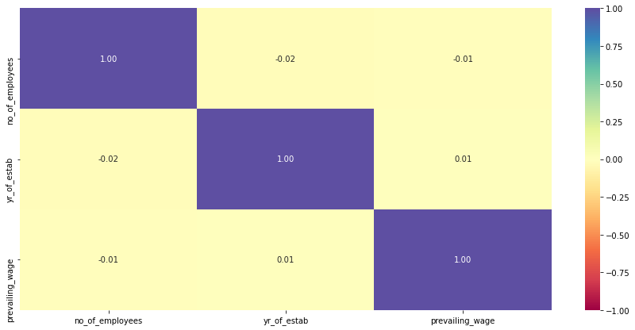

```python
numeric_columns = bc.select_dtypes(include=np.number).columns.tolist()

# correlation heatmap
plt.figure(figsize=(15, 7))
sns.heatmap(
    bc[numeric_columns].corr(),
    annot=True,
    vmin=-1,
    vmax=1,
    fmt=".2f",
    cmap="Spectral"
)
plt.show()
```

### Outlier Processing

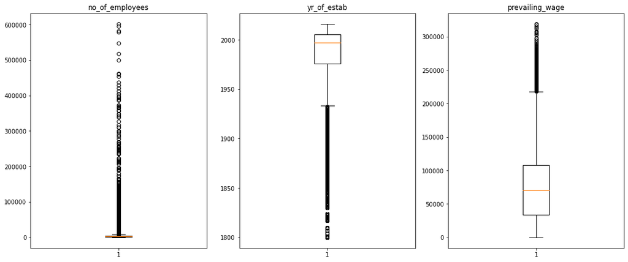

```python
# let's plot the boxplots of all columns to check for outliers
plt.figure(figsize=(20, 30))

for i, variable in enumerate(numeric_columns):
    plt.subplot(5, 4, i + 1)
    plt.boxplot(bc[variable], whis=1.5)
    plt.tight_layout()
    plt.title(variable)

plt.show()
```

#### Observations

1. The three numerical variables all have large numbers of outliers
2. However, these outliers make sense in light of he data provided and as such will not be treated.
3. Only, the negative employees will be treated

### Outlier Treatment

```python
# Drop observations with negative employees. This is becasue only 33 rows have negative employee numbers
index_names = bc[ bc['no_of_employees'] < 0 ].index
bc.drop(index_names , inplace = True)
```

```python
bc.describe(include='all').T
```

|  | count | unique | top | freq | mean | std | min | 25% | 50% | 75% | max |
| --- | --- | --- | --- | --- | --- | --- | --- | --- | --- | --- | --- |
| case_id | 25447 | 25447 | EZYV01 | 1 | NaN | NaN | NaN | NaN | NaN | NaN | NaN |
| continent | 25447 | 6 | Asia | 16840 | NaN | NaN | NaN | NaN | NaN | NaN | NaN |
| education_of_employee | 25447 | 4 | Bachelor's | 10220 | NaN | NaN | NaN | NaN | NaN | NaN | NaN |
| has_job_experience | 25447 | 2 | Y | 14786 | NaN | NaN | NaN | NaN | NaN | NaN | NaN |
| requires_job_training | 25447 | 2 | N | 22498 | NaN | NaN | NaN | NaN | NaN | NaN | NaN |
| no_of_employees | 25447.0 | NaN | NaN | NaN | 5674.415334 | 22891.842245 | 12.0 | 1025.0 | 2112.0 | 3506.5 | 602069.0 |
| yr_of_estab | 25447.0 | NaN | NaN | NaN | 1979.394506 | 42.385932 | 1800.0 | 1976.0 | 1997.0 | 2005.0 | 2016.0 |
| region_of_employment | 25447 | 5 | Northeast | 7189 | NaN | NaN | NaN | NaN | NaN | NaN | NaN |
| prevailing_wage | 25447.0 | NaN | NaN | NaN | 74468.281479 | 52822.17737 | 2.1367 | 34039.21 | 70312.5 | 107739.505 | 319210.27 |
| unit_of_wage | 25447 | 4 | Year | 22933 | NaN | NaN | NaN | NaN | NaN | NaN | NaN |
| full_time_position | 25447 | 2 | Y | 22741 | NaN | NaN | NaN | NaN | NaN | NaN | NaN |
| case_status | 25447 | 2 | Certified | 17001 | NaN | NaN | NaN | NaN | NaN | NaN | NaN |

# Model Building

1. We want to predict the visa status of the staff.
2. Before we proceed to build a model, we'll have to encode categorical features.
3. We'll split the data into train and test to be able to evaluate the model that we build on the train data.

```python
##replacing case_status with 0 and 1
##getting dummies

replaceStruct = {"case_status":     {"Certified": 1, "Denied": 0} }
```

```python
bc=bc.replace(replaceStruct)
bc.head()
```

|  | case_id | continent | education_of_employee | has_job_experience | requires_job_training | no_of_employees | yr_of_estab | region_of_employment | prevailing_wage | unit_of_wage | full_time_position | case_status |
| --- | --- | --- | --- | --- | --- | --- | --- | --- | --- | --- | --- | --- |
| 0 | EZYV01 | Asia | High School | N | N | 14513 | 2007 | West | 592.2029 | Hour | Y | 0 |
| 1 | EZYV02 | Asia | Master's | Y | N | 2412 | 2002 | Northeast | 83425.6500 | Year | Y | 1 |
| 2 | EZYV03 | Asia | Bachelor's | N | Y | 44444 | 2008 | West | 122996.8600 | Year | Y | 0 |
| 3 | EZYV04 | Asia | Bachelor's | N | N | 98 | 1897 | West | 83434.0300 | Year | Y | 0 |
| 4 | EZYV05 | Africa | Master's | Y | N | 1082 | 2005 | South | 149907.3900 | Year | Y | 1 |

```python
# defining x and y variables
x = bc.drop(["case_status",'case_id'], axis=1)
y = bc["case_status"]

print(x.head())
print(y.head())
```

```
  continent education_of_employee has_job_experience requires_job_training  \
0      Asia           High School                  N                     N
1      Asia              Master's                  Y                     N
2      Asia            Bachelor's                  N                     Y
3      Asia            Bachelor's                  N                     N
4    Africa              Master's                  Y                     N

   no_of_employees  yr_of_estab region_of_employment  prevailing_wage  \
0            14513         2007                 West         592.2029
1             2412         2002            Northeast       83425.6500
2            44444         2008                 West      122996.8600
3               98         1897                 West       83434.0300
4             1082         2005                South      149907.3900

  unit_of_wage full_time_position
0         Hour                  Y
1         Year                  Y
2         Year                  Y
3         Year                  Y
4         Year                  Y
0    0
1    1
2    0
3    0
4    1
Name: case_status, dtype: int64
```

```python
x = pd.get_dummies(
    x,
    columns=x.select_dtypes(include=["object", "category"]).columns.tolist(),
    drop_first=True,
)
x.head()
```

|  | no_of_employees | yr_of_estab | prevailing_wage | continent_Asia | continent_Europe | continent_North America | continent_Oceania | continent_South America | education_of_employee_Doctorate | education_of_employee_High School | education_of_employee_Master's | has_job_experience_Y | requires_job_training_Y | region_of_employment_Midwest | region_of_employment_Northeast | region_of_employment_South | region_of_employment_West | unit_of_wage_Month | unit_of_wage_Week | unit_of_wage_Year | full_time_position_Y |
| --- | --- | --- | --- | --- | --- | --- | --- | --- | --- | --- | --- | --- | --- | --- | --- | --- | --- | --- | --- | --- | --- |
| 0 | 14513 | 2007 | 592.2029 | 1 | 0 | 0 | 0 | 0 | 0 | 1 | 0 | 0 | 0 | 0 | 0 | 0 | 1 | 0 | 0 | 0 | 1 |
| 1 | 2412 | 2002 | 83425.6500 | 1 | 0 | 0 | 0 | 0 | 0 | 0 | 1 | 1 | 0 | 0 | 1 | 0 | 0 | 0 | 0 | 1 | 1 |
| 2 | 44444 | 2008 | 122996.8600 | 1 | 0 | 0 | 0 | 0 | 0 | 0 | 0 | 0 | 1 | 0 | 0 | 0 | 1 | 0 | 0 | 1 | 1 |
| 3 | 98 | 1897 | 83434.0300 | 1 | 0 | 0 | 0 | 0 | 0 | 0 | 0 | 0 | 0 | 0 | 0 | 0 | 1 | 0 | 0 | 1 | 1 |
| 4 | 1082 | 2005 | 149907.3900 | 0 | 0 | 0 | 0 | 0 | 0 | 0 | 1 | 1 | 0 | 0 | 0 | 1 | 0 | 0 | 0 | 1 | 1 |

```python
x_train, x_test, y_train, y_test = train_test_split(x, y, test_size=.30, random_state=1,stratify=y)
print(x_train.shape, x_test.shape)
```

```
(17812, 21) (7635, 21)
```

```python
y.value_counts(1)
```

```
1    0.668094
0    0.331906
Name: case_status, dtype: float64
```

```python
y_test.value_counts(1)
```

```
1    0.668107
0    0.331893
Name: case_status, dtype: float64
```

```python
#### Calculation of Metrics and Confusion Matrix

## Function to create confusion matrix
def make_confusion_matrix(model,y_actual,labels=[1, 0]):
    '''
    model : classifier to predict values of x
    y_actual : ground truth

    '''
    y_predict = model.predict(x_test)
    cm=metrics.confusion_matrix( y_actual, y_predict, labels=[0, 1])
    df_cm = pd.DataFrame(cm, index = [i for i in ["Actual - No","Actual - Yes"]],
                  columns = [i for i in ['Predicted - No','Predicted - Yes']])
    group_counts = ["{0:0.0f}".format(value) for value in
                cm.flatten()]
    group_percentages = ["{0:.2%}".format(value) for value in
                         cm.flatten()/np.sum(cm)]
    labels = [f"{v1}\n{v2}" for v1, v2 in
              zip(group_counts,group_percentages)]
    labels = np.asarray(labels).reshape(2,2)
    plt.figure(figsize = (10,7))
    sns.heatmap(df_cm, annot=labels,fmt='')
    plt.ylabel('True label')
    plt.xlabel('Predicted label')
```

```python
##  Function to calculate different metric scores of the model - Accuracy, Recall and Precision
def get_metrics_score(model,flag=True):
    '''
    model : classifier to predict values of x

    '''
    # defining an empty list to store train and test results
    score_list=[]

    #Predicting on train and tests
    pred_train = model.predict(x_train)
    pred_test = model.predict(x_test)

    #Accuracy of the model
    train_acc = model.score(x_train,y_train)
    test_acc = model.score(x_test,y_test)

    #Recall of the model
    train_recall = metrics.recall_score(y_train,pred_train)
    test_recall = metrics.recall_score(y_test,pred_test)

    #Precision of the model
    train_precision = metrics.precision_score(y_train,pred_train)
    test_precision = metrics.precision_score(y_test,pred_test)

    score_list.extend((train_acc,test_acc,train_recall,test_recall,train_precision,test_precision))

    # If the flag is set to True then only the following print statements will be dispayed. The default value is set to True.
    if flag == True:
        print("Accuracy on training set : ",model.score(x_train,y_train))
        print("Accuracy on test set : ",model.score(x_test,y_test))
        print("Recall on training set : ",metrics.recall_score(y_train,pred_train))
        print("Recall on test set : ",metrics.recall_score(y_test,pred_test))
        print("Precision on training set : ",metrics.precision_score(y_train,pred_train))
        print("Precision on test set : ",metrics.precision_score(y_test,pred_test))

    return score_list # returning the list with train and test scores
```

# Model Building

## Bagging Classifier

```python
#base_estimator for bagging classifier is a decision tree by default
bagging_estimator=BaggingClassifier(random_state=1)
bagging_estimator.fit(x_train,y_train)
```

```
BaggingClassifier(random_state=1)
```

```python
#Using above defined function to get accuracy, recall and precision on train and test set
bagging_estimator_score=get_metrics_score(bagging_estimator)
```

```
Accuracy on training set :  0.9846732539860769
Accuracy on test set :  0.7012442698100851
Recall on training set :  0.9858823529411764
Recall on test set :  0.7792589688296413
Precision on training set :  0.9911295091661738
Precision on test set :  0.7748538011695907
```

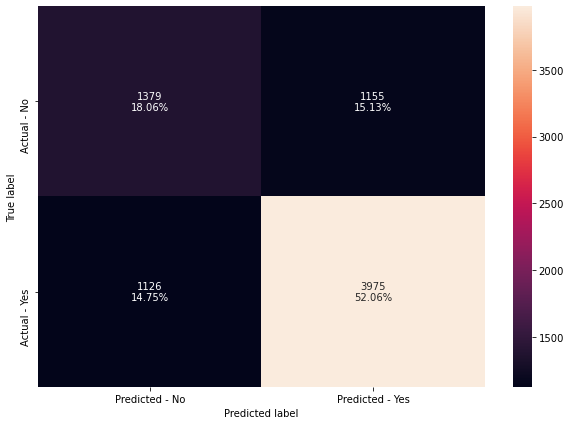

```python
make_confusion_matrix(bagging_estimator,y_test)
```

### Random Forest Classifier

```python
#Train the random forest classifier
rf_estimator=RandomForestClassifier(random_state=1)
rf_estimator.fit(x_train,y_train)
```

```
RandomForestClassifier(random_state=1)
```

```python
#Using above defined function to get accuracy, recall and precision on train and test set
rf_estimator_score=get_metrics_score(rf_estimator)
```

```
Accuracy on training set :  1.0
Accuracy on test set :  0.7210216110019646
Recall on training set :  1.0
Recall on test set :  0.832973926681043
Precision on training set :  1.0
Precision on test set :  0.7687714854351366
```

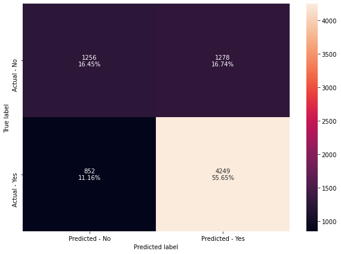

```python
make_confusion_matrix(rf_estimator,y_test)
```

#### Observations

1. Both models - Bagging classifiers as well as random forest classifier are overfitting the train data.
2. Both models are giving similar performance in terms of accuracy but random forest classifier is giving better recall.

## Hyperparameter Tuning

### Bagging Classifier

```python
# Choose the type of classifier.
bagging_estimator_tuned = BaggingClassifier(random_state=1)

# Grid of parameters to choose from
## add from article
parameters = {'max_samples': [0.7,0.8,0.9,1],
              'max_features': [0.7,0.8,0.9,1],
              'n_estimators' : [10,20,30,40,50],
             }

# Type of scoring used to compare parameter combinations
acc_scorer = metrics.make_scorer(metrics.recall_score)

# Run the grid search
grid_obj = GridSearchCV(bagging_estimator_tuned, parameters, scoring=acc_scorer,cv=5)
grid_obj = grid_obj.fit(x_train, y_train)

# Set the clf to the best combination of parameters
bagging_estimator_tuned = grid_obj.best_estimator_

# Fit the best algorithm to the data.
bagging_estimator_tuned.fit(x_train, y_train)
```

```
BaggingClassifier(max_features=0.7, max_samples=1, n_estimators=30,
                  random_state=1)
```

```python
#Using above defined function to get accuracy, recall and precision on train and test set
bagging_estimator_tuned_score=get_metrics_score(bagging_estimator_tuned)
```

```
Accuracy on training set :  0.6680889288120369
Accuracy on test set :  0.6681074001309758
Recall on training set :  1.0
Recall on test set :  1.0
Precision on training set :  0.6680889288120369
Precision on test set :  0.6681074001309758
```

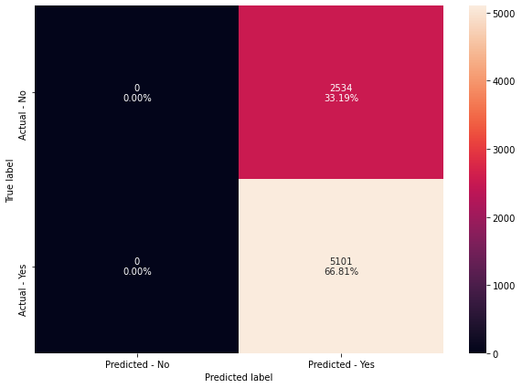

```python
make_confusion_matrix(bagging_estimator_tuned,y_test)
```

#### Observations

1. We can see that train accuracy reduced while the train recall for the bagging classifier increased slightly after hyperparameter tuning. However the test recall has increased significantly.
2. The model is not overfitting the data, as train accuracy and recall very close to the test accuracy and test recall.

### Logistic Regression

```python
bagging_lr=BaggingClassifier(base_estimator=LogisticRegression(solver='liblinear',random_state=1,max_iter=1000),random_state=1)
bagging_lr.fit(x_train,y_train)
```

```
BaggingClassifier(base_estimator=LogisticRegression(max_iter=1000,
                                                    random_state=1,
                                                    solver='liblinear'),
                  random_state=1)
```

```python
#Using above defined function to get accuracy, recall and precision on train and test set
bagging_lr_score=get_metrics_score(bagging_lr)
```

```
Accuracy on training set :  0.6680889288120369
Accuracy on test set :  0.6681074001309758
Recall on training set :  1.0
Recall on test set :  1.0
Precision on training set :  0.6680889288120369
Precision on test set :  0.6681074001309758
```

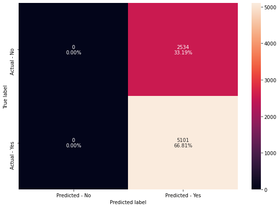

```python
make_confusion_matrix(bagging_lr,y_test)
```

#### Observations

1. Bagging classifier with logistic regression as base_estimator is not overfitting the data and the test recall is very high.
2. Ensemble models are less interpretable than decision tree but bagging classifier is even less interpretable than random forest. It does not even have a feature importance attribute.

### Random Forest Classifier

```python
# Choose the type of classifier.
rf_estimator_tuned = RandomForestClassifier(random_state=1)

# Grid of parameters to choose from
## add from article
parameters = {"n_estimators": [150,200,250],
    "min_samples_leaf": np.arange(5, 10),
    "max_features": np.arange(0.2, 0.7, 0.1),
    "max_samples": np.arange(0.3, 0.7, 0.1),
             }

# Type of scoring used to compare parameter combinations
acc_scorer = metrics.make_scorer(metrics.recall_score)

# Run the grid search
grid_obj = GridSearchCV(rf_estimator_tuned, parameters, scoring=acc_scorer,cv=5)
grid_obj = grid_obj.fit(x_train, y_train)

# Set the clf to the best combination of parameters
rf_estimator_tuned = grid_obj.best_estimator_

# Fit the best algorithm to the data.
rf_estimator_tuned.fit(x_train, y_train)
```

```
RandomForestClassifier(max_features=0.2, max_samples=0.3, min_samples_leaf=8,
                       n_estimators=250, random_state=1)
```

```python
#Using above defined function to get accuracy, recall and precision on train and test set
rf_estimator_tuned_score=get_metrics_score(rf_estimator_tuned)
```

```
Accuracy on training set :  0.7625757916011677
Accuracy on test set :  0.7481335952848723
Recall on training set :  0.8848739495798319
Recall on test set :  0.8710056851597726
Precision on training set :  0.7864665023526776
Precision on test set :  0.7783812193412754
```

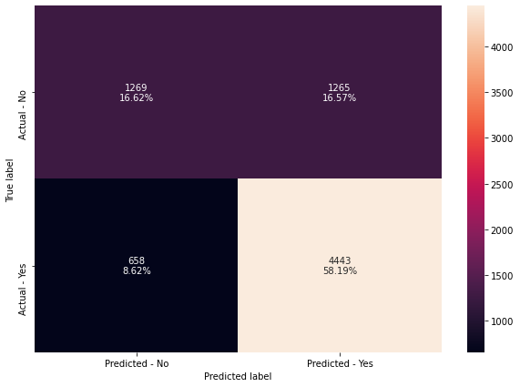

```python
make_confusion_matrix(rf_estimator_tuned,y_test)
```

#### Observations

1. We see that random forest's performance has increased as compared to the random forest model with default parameters.
2. Model is slightly overfitting the data a bit more than the tuned bagging classifier.
3. The test recall is very high low. This means that the model is quite good at identifying visa certified candidates which is our primary aim here.

### Class Weights

```python
# Choose the type of classifier.
rf_estimator_weighted = RandomForestClassifier(random_state=1)

# Grid of parameters to choose from
## add from article
parameters = {
    "class_weight": [{0: 0.3, 1: 0.7}],
    "n_estimators": [100,150,200,250],
    "min_samples_leaf": np.arange(5, 10),
    "max_features": np.arange(0.2, 0.7, 0.1),
    "max_samples": np.arange(0.3, 0.7, 0.1),
}

# Type of scoring used to compare parameter combinations
acc_scorer = metrics.make_scorer(metrics.recall_score)

# Run the grid search
grid_obj = GridSearchCV(rf_estimator_weighted, parameters, scoring=acc_scorer,cv=5)
grid_obj = grid_obj.fit(x_train, y_train)

# Set the clf to the best combination of parameters
rf_estimator_weighted = grid_obj.best_estimator_

# Fit the best algorithm to the data.
rf_estimator_weighted.fit(x_train, y_train)
```

```
RandomForestClassifier(class_weight={0: 0.3, 1: 0.7}, max_features=0.2,
                       max_samples=0.3, min_samples_leaf=9, random_state=1)
```

```python
#Using above defined function to get accuracy, recall and precision on train and test set
rf_estimator_weighted_score=get_metrics_score(rf_estimator_weighted)
```

```
Accuracy on training set :  0.7168762631933528
Accuracy on test set :  0.7047806155861166
Recall on training set :  0.9826890756302521
Recall on test set :  0.9729464810821408
Precision on training set :  0.7073982215231989
Precision on test set :  0.7010877242548382
```

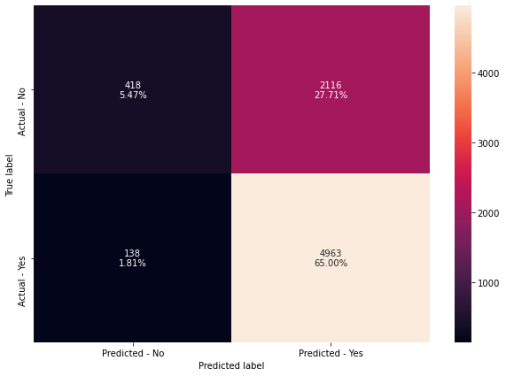

```python
make_confusion_matrix(rf_estimator_weighted,y_test)
```

### Feature Importance

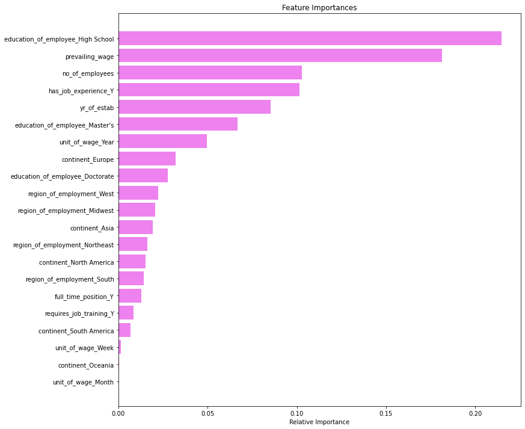

```python
importances = rf_estimator_weighted.feature_importances_
indices = np.argsort(importances)
feature_names = list(x.columns)

plt.figure(figsize=(12,12))
plt.title('Feature Importances')
plt.barh(range(len(indices)), importances[indices], color='violet', align='center')
plt.yticks(range(len(indices)), [feature_names[i] for i in indices])
plt.xlabel('Relative Importance')
plt.show()
```

#### Observations

The top 4 features are:  
a. High school education  
b. pevailing wage  
c. number of employees  
d. job experience

### Model Comparison

```python
# defining list of models
models = [bagging_estimator,bagging_estimator_tuned,bagging_lr,rf_estimator,rf_estimator_tuned,
          rf_estimator_weighted]

# defining empty lists to add train and test results
acc_train = []
acc_test = []
recall_train = []
recall_test = []
precision_train = []
precision_test = []

# looping through all the models to get the accuracy, precall and precision scores
for model in models:
    j = get_metrics_score(model,False)
    acc_train.append(np.round(j[0],2))
    acc_test.append(np.round(j[1],2))
    recall_train.append(np.round(j[2],2))
    recall_test.append(np.round(j[3],2))
    precision_train.append(np.round(j[4],2))
    precision_test.append(np.round(j[5],2))
```

```python
comparison_frame = pd.DataFrame({'Model':['Bagging classifier with default parameters','Tuned Bagging Classifier',
                                        'Bagging classifier with base_estimator=LR', 'Random Forest with deafult parameters',
                                         'Tuned Random Forest Classifier','Random Forest with class_weights'],
                                          'Train_Accuracy': acc_train,'Test_Accuracy': acc_test,
                                          'Train_Recall':recall_train,'Test_Recall':recall_test,
                                          'Train_Precision':precision_train,'Test_Precision':precision_test})
comparison_frame
```

|  | Model | Train_Accuracy | Test_Accuracy | Train_Recall | Test_Recall | Train_Precision | Test_Precision |
| --- | --- | --- | --- | --- | --- | --- | --- |
| 0 | Bagging classifier with default parameters | 0.98 | 0.70 | 0.99 | 0.78 | 0.99 | 0.77 |
| 1 | Tuned Bagging Classifier | 0.67 | 0.67 | 1.00 | 1.00 | 0.67 | 0.67 |
| 2 | Bagging classifier with base_estimator=LR | 0.67 | 0.67 | 1.00 | 1.00 | 0.67 | 0.67 |
| 3 | Random Forest with deafult parameters | 1.00 | 0.72 | 1.00 | 0.83 | 1.00 | 0.77 |
| 4 | Tuned Random Forest Classifier | 0.76 | 0.75 | 0.88 | 0.87 | 0.79 | 0.78 |
| 5 | Random Forest with class_weights | 0.72 | 0.70 | 0.98 | 0.97 | 0.71 | 0.70 |

## Boosting Classifier

### AdaBoost Classifier

```python
abc = AdaBoostClassifier(random_state=1)
abc.fit(x_train,y_train)
```

```
AdaBoostClassifier(random_state=1)
```

```python
#Using above defined function to get accuracy, recall and precision on train and test set
abc_score=get_metrics_score(abc)
```

```
Accuracy on training set :  0.7405681562991242
Accuracy on test set :  0.7338572364112639
Recall on training set :  0.8908403361344538
Recall on test set :  0.8774750049009998
Precision on training set :  0.7614019966961143
Precision on test set :  0.7608363080061193
```

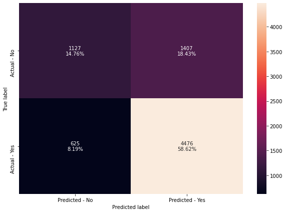

```python
make_confusion_matrix(abc,y_test)
```

### Gradient Boosting

```python
gbc = GradientBoostingClassifier(random_state=1)
gbc.fit(x_train,y_train)
```

```
GradientBoostingClassifier(random_state=1)
```

```python
#Using above defined function to get accuracy, recall and precision on train and test set
gbc_score=get_metrics_score(gbc)
```

```
Accuracy on training set :  0.7572423085560297
Accuracy on test set :  0.7476096922069417
Recall on training set :  0.8805042016806722
Recall on test set :  0.8678690452852382
Precision on training set :  0.7831091180866966
Precision on test set :  0.7794014084507043
```

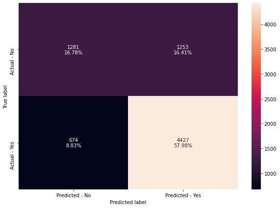

```python
make_confusion_matrix(gbc,y_test)
```

#### Observations

1. Both models are very close in terms of test recall, test accuracy and test precision

## Hyperparameter Tuning

### Adaboost Classifier

```python
# Choose the type of classifier.
abc_tuned = AdaBoostClassifier(random_state=1)

# Grid of parameters to choose from
## add from article
parameters = {
    #Let's try different max_depth for base_estimator
    "base_estimator":[DecisionTreeClassifier(max_depth=1, random_state=1),DecisionTreeClassifier(max_depth=2, random_state=1),DecisionTreeClassifier(max_depth=3, random_state=1)],
    "n_estimators": np.arange(10,110,10),
    "learning_rate":np.arange(0.1,2,0.1)
}

# Type of scoring used to compare parameter combinations
acc_scorer = metrics.make_scorer(metrics.recall_score)

# Run the grid search
grid_obj = GridSearchCV(abc_tuned, parameters, scoring=acc_scorer,cv=5)
grid_obj = grid_obj.fit(x_train, y_train)

# Set the clf to the best combination of parameters
abc_tuned = grid_obj.best_estimator_

# Fit the best algorithm to the data.
abc_tuned.fit(x_train, y_train)
```

```
AdaBoostClassifier(base_estimator=DecisionTreeClassifier(max_depth=1,
                                                         random_state=1),
                   learning_rate=0.1, n_estimators=20, random_state=1)
```

```python
#Using above defined function to get accuracy, recall and precision on train and test set
abc_tuned_score=get_metrics_score(abc_tuned)
```

```
Accuracy on training set :  0.6916123961374354
Accuracy on test set :  0.6910281597904387
Recall on training set :  0.9715966386554622
Recall on test set :  0.9684375612624976
Precision on training set :  0.6916312735538673
Precision on test set :  0.6920706080134491
```

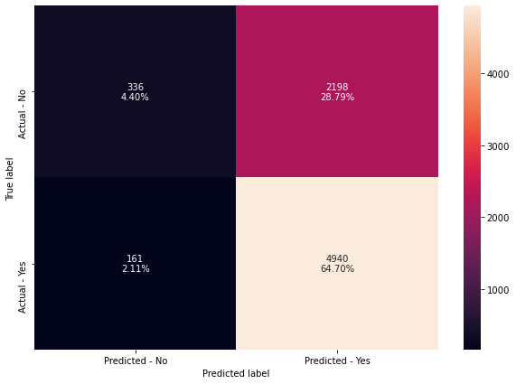

```python
make_confusion_matrix(abc_tuned,y_test)
```

#### Observations

1. The model is not overfitting the train data as train accuracy is very close to the test accuracy.
2. The model has a very high test recall. This implies that the model is good at identifying visa certified individuals.

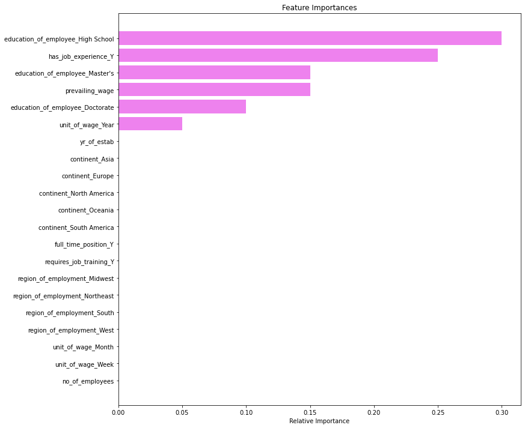

```python
importances = abc_tuned.feature_importances_
indices = np.argsort(importances)
feature_names = list(x.columns)

plt.figure(figsize=(12,12))
plt.title('Feature Importances')
plt.barh(range(len(indices)), importances[indices], color='violet', align='center')
plt.yticks(range(len(indices)), [feature_names[i] for i in indices])
plt.xlabel('Relative Importance')
plt.show()
```

### Gradient Booster Classifier

```python
gbc_init = GradientBoostingClassifier(init=AdaBoostClassifier(random_state=1),random_state=1)
gbc_init.fit(x_train,y_train)
```

```
GradientBoostingClassifier(init=AdaBoostClassifier(random_state=1),
                           random_state=1)
```

```python
#Using above defined function to get accuracy, recall and precision on train and test set
gbc_init_score=get_metrics_score(gbc_init)
```

```
Accuracy on training set :  0.7566808892881204
Accuracy on test set :  0.7489194499017682
Recall on training set :  0.8789915966386554
Recall on test set :  0.867280925308763
Precision on training set :  0.7832859068443911
Precision on test set :  0.7810734463276836
```

#### Observations (compared to Default Model)

1. There is very negligible difference between the models

```python
# Choose the type of classifier.
gbc_tuned = GradientBoostingClassifier(init=AdaBoostClassifier(random_state=1),random_state=1)

# Grid of parameters to choose from
## add from article
parameters = {
    "n_estimators": [100,150,200,250],
    "subsample":[0.8,0.9,1],
    "max_features":[0.7,0.8,0.9,1]
}

# Type of scoring used to compare parameter combinations
acc_scorer = metrics.make_scorer(metrics.recall_score)

# Run the grid search
grid_obj = GridSearchCV(gbc_tuned, parameters, scoring=acc_scorer,cv=5)
grid_obj = grid_obj.fit(x_train, y_train)

# Set the clf to the best combination of parameters
gbc_tuned = grid_obj.best_estimator_

# Fit the best algorithm to the data.
gbc_tuned.fit(x_train, y_train)
```

```
GradientBoostingClassifier(init=AdaBoostClassifier(random_state=1),
                           max_features=1, random_state=1, subsample=1)
```

```python
#Using above defined function to get accuracy, recall and precision on train and test set
gbc_tuned_score=get_metrics_score(gbc_tuned)
```

```
Accuracy on training set :  0.7327082865483944
Accuracy on test set :  0.7259986902423051
Recall on training set :  0.9242016806722689
Recall on test set :  0.9155067633797295
Precision on training set :  0.7402571178569025
Precision on test set :  0.7376401832253988
```

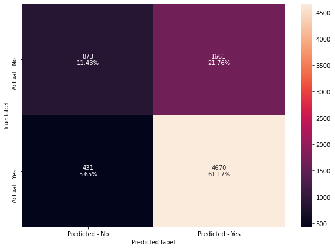

```python
make_confusion_matrix(gbc_tuned,y_test)
```

#### Observations

1. The model performace has not increased by much except in terms of recall which has seen asignificant jump.
2. Both test and train recall are very close to each other indicating that the model is not overfitting.
3. It is better at identifying certified which is the aim of the model.

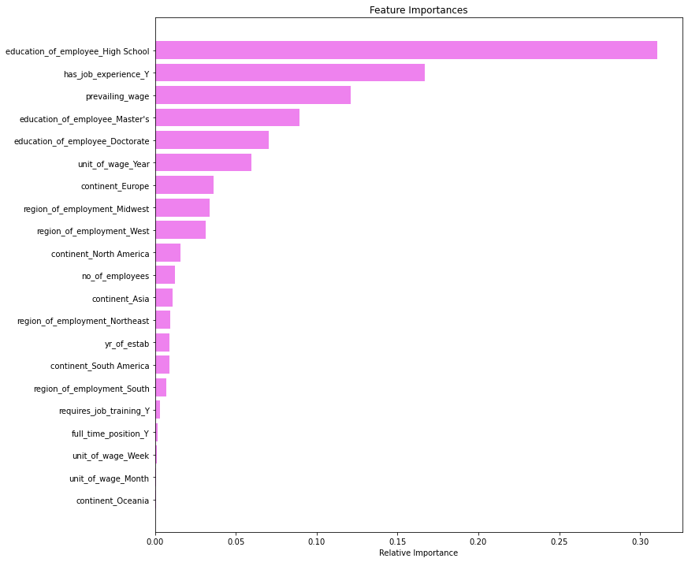

```python
importances = gbc_tuned.feature_importances_
indices = np.argsort(importances)
feature_names = list(x.columns)

plt.figure(figsize=(12,12))
plt.title('Feature Importances')
plt.barh(range(len(indices)), importances[indices], color='violet', align='center')
plt.yticks(range(len(indices)), [feature_names[i] for i in indices])
plt.xlabel('Relative Importance')
plt.show()
```

#### Observations

1. High school education is the most important factor.
2. Masters education, job experience and prevailing wage all seem are the next most important factors

### Model Comparison

```python
# defining list of models
models = [abc, abc_tuned, gbc, gbc_init, gbc_tuned]

# defining empty lists to add train and test results
acc_train = []
acc_test = []
recall_train = []
recall_test = []
precision_train = []
precision_test = []

# looping through all the models to get the accuracy, precall and precision scores
for model in models:
    j = get_metrics_score(model,False)
    acc_train.append(np.round(j[0],2))
    acc_test.append(np.round(j[1],2))
    recall_train.append(np.round(j[2],2))
    recall_test.append(np.round(j[3],2))
    precision_train.append(np.round(j[4],2))
    precision_test.append(np.round(j[5],2))
```

```python
comparison_frame = pd.DataFrame({'Model':['AdaBoost with default paramters','AdaBoost Tuned',
                                          'Gradient Boosting with default parameters','Gradient Boosting with init=AdaBoost',
                                          'Gradient Boosting Tuned'],
                                          'Train_Accuracy': acc_train,'Test_Accuracy': acc_test,
                                          'Train_Recall':recall_train,'Test_Recall':recall_test,
                                          'Train_Precision':precision_train,'Test_Precision':precision_test})
comparison_frame
```

|  | Model | Train_Accuracy | Test_Accuracy | Train_Recall | Test_Recall | Train_Precision | Test_Precision |
| --- | --- | --- | --- | --- | --- | --- | --- |
| 0 | AdaBoost with default paramters | 0.74 | 0.73 | 0.89 | 0.88 | 0.76 | 0.76 |
| 1 | AdaBoost Tuned | 0.69 | 0.69 | 0.97 | 0.97 | 0.69 | 0.69 |
| 2 | Gradient Boosting with default parameters | 0.76 | 0.75 | 0.88 | 0.87 | 0.78 | 0.78 |
| 3 | Gradient Boosting with init=AdaBoost | 0.76 | 0.75 | 0.88 | 0.87 | 0.78 | 0.78 |
| 4 | Gradient Boosting Tuned | 0.73 | 0.73 | 0.92 | 0.92 | 0.74 | 0.74 |

#### Observations

1. The *Gradient Boosting Tuned* model is the best model here. It has both a very high recall score paired with a sufficiently high accuracy.
2. *Random Forest with Class weights* and *AdaBoost tuned* are the next top models. They both give a similar performance.

# Conclusion and Recommendation

## Conclusion

Due to the high number of visa applications for the limited number of jobs, a profile of the 'ideal' visa candidate is needed in order to facilitate a smoother, more effective and correct visa approval process. based on the data analysed above, the most important factors in approving Visas, have been determined. They include, but are not limited to

1. Minimum of a high school education
2. The prevailing wage of the company/industry
3. Job experience of the candidate
4. Location of candidate
5. Region of employment
6. Type of wage candiate is willing to work for

Based on all these factors, the ability of the model to properly classify and predict which candidate is going to be certified will enable their time and resources more effectively and efficiently. The classification model chosen is *Tuned Gradient Boosting Model* because it has both a very high recall score paired with a sufficiently high accuracy.

## Recommendations

Based on the analysis, these are the following recommendations that can help the business determine what criteria should be used for Visa approval and help facilitate the process for Visa approval:

1. As Asia has the highest number of applications, a dedicated Asia section should be created. This is done to handle the high number of cases from that specific continent
2. The other regions can be grouped together for the time being, until they become bigger and contribute more
3. The regions with the largest number of applicants should also be investigated in order understand why they are coming from there and why there is a disconnect between the number of applications and certified status
4. Special focus should be paid on low contributing continents in order to drum up business by introducing special rates and promotions.
5. The company can partner with schools in order to grow the number of candidates with degrees so as to increase certified statuses
6. Companies should be split into two concerning job experience and type of position and clearly indicated on the site
7. The company needs to identify a minimum requirement/criteria list from each region/company/industry so that applicants are aware of what they are applying for. This will enable immediate weeding out

The ideal profile for a certified applicant should consist of the following characteristics:

1. Minimum of Bachelors degree
2. Applying to regions that is known for having a lot of certified applicants
3. Relevant job experience
4. Prevailing wage of the industry

*This profile should be circulated to all aspirational candidates so they can be forewarned before applying*  
This profile is subject to adjustment by the company